# DS4SI-final

Fourth, we build multilevel models to predict (1) raw individual perforamnce score and (2) the relative strength score using country-level GGGI, controlling for other individual level confounders. Using only the first plausible score (a recommended unbiased shortcut as recommended by the PISA data manual), We found that GGGI does not interact with gender to predict either the raw science performance score or the science performance relative to the overall performance in science, reading and math. This finding provides is contrary to the main findings in the original paper, potentially because we considered the multilevel structure of the data. Importantly, although we attempted to add individual level covariates, the models mostly failed to converge.

```r
dat.s <- dat %>% select(CNTRYID, CNTSCHID, CNTSTUID,
                            ST001D01T,ST004D01T, SMINS,
                            TMINS, ESCS, REPEAT,
                            IMMIG, JOYSCIE, INTBRSCI,
                            INSTSCIE,SCIEEFF,EPIST,
                            SCIEACT, MOTIVAT, W_FSTUWT, PV1SCIE, PV1READ, PV1MATH)

names(dat.s) <- c("country", "schid", "id",
                "grade","gender", "science_time",
                "total_time","ses", "graderepeat",
                "immigration", "sci_enjoy","sci_interest",
                "sci_instrument","sci_efficacy","sci_epist",
                "sci_activity", "sci_motivation", "weight", "pv1scie", "pv1read", "pv1math"
                )

# turn factor into numeric
for (i in 11:17) {
  dat.s[,i] <- as.numeric(as.character(dat.s[,i]))
}

dat.s$scie_rel <- rowMeans(dat.s[,c("pv1scie", "pv1read", "pv1math")], na.rm = T)
dat.s$scie_rel <- dat.s$pv1scie - dat.s$scie_rel


dat.s <- left_join(dat.s, cdat, by = "country")

fit1 <- lmer(pv1scie ~ 1 + gender +
              (1 | schid:country) + # level 2 random effect
              (1 + gender | country ), # level 3 random effect
           weights = weight, data = dat.s)

fit2 <- lmer(pv1scie ~ 1 + gender * GGI +
              (1 | schid:country) + # level 2 random effect
              (1 + gender | country ), # level 3 random effect
           weights = weight, data = dat.s)

fit3 <- lmer(scie_rel ~ 1 + gender +
              (1 | schid:country) + # level 2 random effect
              (1 + gender | country ), # level 3 random effect
           weights = weight, data = dat.s)

fit4 <- lmer(scie_rel ~ 1 + gender * GGI +
              (1 | schid:country) + # level 2 random effect
              (1 + gender | country ), # level 3 random effect
           weights = weight, data = dat.s)

# model won't converge well with covariates


texreg::htmlreg(list(fit1, fit2, fit3, fit4),
                  custom.model.names = c("Raw score", "Raw score",
                                         "Relative score", "Relative score"),
                  digits = 3)
```

Statistical models

|  | Raw score | Raw score | Relative score | Relative score |
| --- | --- | --- | --- | --- |
| (Intercept) | 461.409*** | 125.989 | -0.473 | 35.003* |
|  | (5.797) | (64.289) | (0.808) | (13.716) |
| genderMale | 5.331*** | -19.044 | 7.779*** | -10.409 |
|  | (1.258) | (18.399) | (0.376) | (328.244) |
| GGI |  | 463.213*** |  | -49.727** |
|  |  | (89.306) |  | (19.058) |
| genderMale:GGI |  | 33.594 |  | 25.424 |
|  |  | (25.607) |  | (455.903) |
| AIC | 6567893.476 | 5670577.375 | 5325552.730 | 4606494.923 |
| BIC | 6567971.598 | 5670676.492 | 5325630.852 | 4606594.040 |
| Log Likelihood | -3283939.738 | -2835279.688 | -2662769.365 | -2303238.461 |
| Num. obs. | 519334 | 448200 | 519334 | 448200 |
| Num. groups: schid:country | 17911 | 15985 | 17911 | 15985 |
| Num. groups: country | 73 | 63 | 73 | 63 |
| Var: schid:country (Intercept) | 2401.544 | 2425.467 | 65.266 | 67.638 |
| Var: country (Intercept) | 2375.413 | 1594.609 | 45.106 | 71.639 |
| Var: country genderMale | 94.412 | 100.878 | 8.451 | 42492.939 |
| Cov: country (Intercept) genderMale | 92.027 | 21.430 | -9.821 | 1226.688 |
| Var: Residual | 254162.872 | 265241.155 | 23859.104 | 25338.437 |

p < 0.001; p < 0.01; p < 0.05

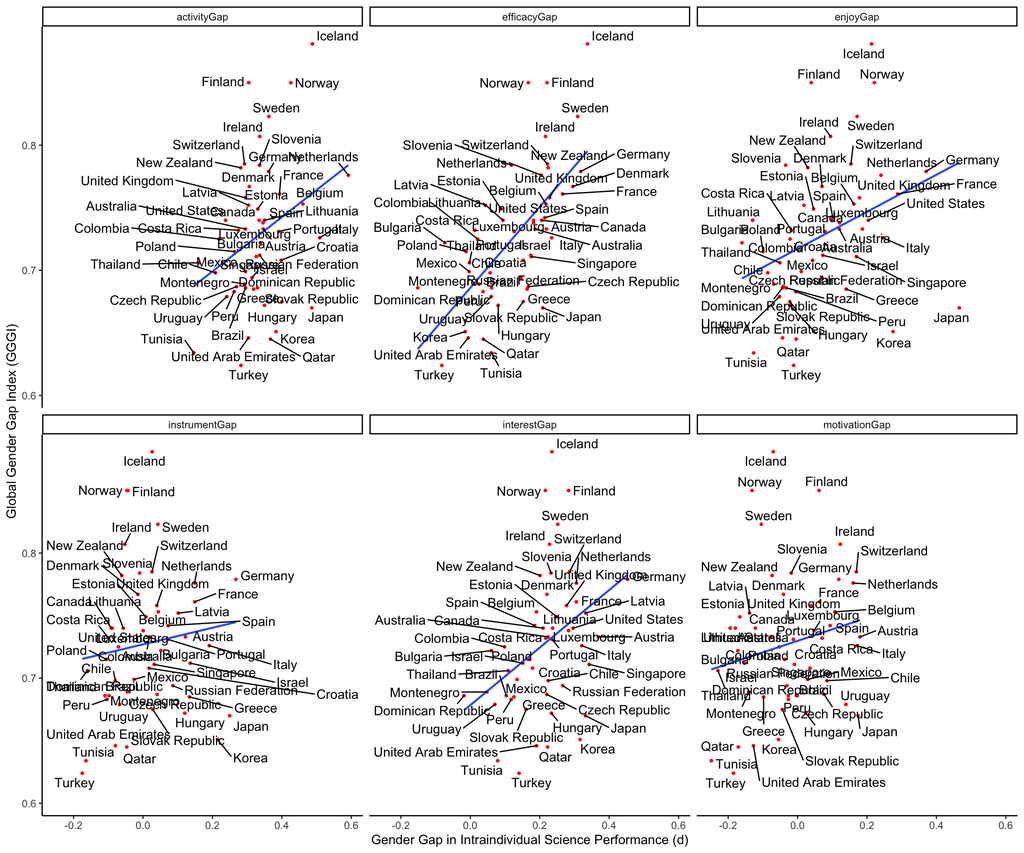

```r
cdat.n.cohend.other <- dat.s %>% group_by(country) %>%
  dplyr::summarize(
    enjoyGap = cohens_d(sci_enjoy[gender == "Male"], sci_enjoy[gender == "Female"]),
    interestGap = cohens_d(sci_interest[gender == "Male"], sci_interest[gender == "Female"]),
    instrumentGap = cohens_d(sci_instrument[gender == "Male"], sci_instrument[gender == "Female"]),
    efficacyGap = cohens_d(sci_efficacy[gender == "Male"], sci_efficacy[gender == "Female"]),
    activityGap = cohens_d(sci_activity[gender == "Male"], sci_activity[gender == "Female"]),
    motivationGap = cohens_d(sci_motivation[gender == "Male"], sci_motivation[gender == "Female"])) %>%
  left_join(., cdat , by = "country")

cdat.n.cohend.other.long <- gather(na.omit(cdat.n.cohend.other), enjoyGap:motivationGap,key = "gap_type", value = "gap")

## plot
ggplot(cdat.n.cohend.other.long, aes(y = GGI, x = gap)) +
  geom_point(color = "red", size = 0.8) +
  geom_smooth(method = "lm", fill = NA, size = 0.8) +
  geom_text_repel(aes(label = country)) +
  facet_wrap(~gap_type) +
  labs(y = "Global Gender Gap Index (GGGI)", x = "Gender Gap in Intraindividual Science Performance (d)") +
  theme_classic()
```